# Loan Default Prediction Model

February 5, 2020

This notebook contains the solution to the BFS Capital interview assignment. It represents a baseline model for predicting which loan issued in 2016 are charge offs. For answers to Q1 and Q2 of the assignment, please scroll to the bottom of the notebook

Note that the model developed in this notebook is for demonstration purposes. When I write code for production, they are typically in version controlled Python scripts organized according to the various steps required for model development.

## Assumptions

- Restrict loans to just "completed" loans: Fully Paid and Charged Off.
  - These two categories marks the end of a loan. Loans that are current, in default, or in grace period may become fully paid or a charge off in the future.
- Model will be used in 2016, thus training will use loans issued from years before 2016
  - Training data years: 2013, 2014, 2015
  - Out-of-sample year: 2016
- Model will be used only on most recent data. As such, features containing data that will not be available at the time when the model will be used is excluded
- Columns that have more than 40% of their observation missing are not useful

## References

- Data source: https://www.kaggle.com/wordsforthewise/lending-club
- Kernel source:
  - https://www.kaggle.com/pileatedperch/predicting-charge-off-from-initial-listing-data
  - https://www.kaggle.com/sishihara/simple-lightgbm-kfold

```python
import pathlib
import importlib

import pandas as pd
import numpy as np
import feather
import seaborn as sns
import matplotlib.pyplot as plt

# custom module containing several helper functions
import utils
importlib.reload(utils)
```

[output not shown]

```
<module 'utils' from '/Users/palermopenano/personal/ds_test/utils.py'>
```

```python
REPO_PATH = '/Users/palermopenano/personal/ds_test'

DATA_PATH = pathlib.Path(REPO_PATH + '/data')
RESULTS_PATH = pathlib.Path(REPO_PATH + '/results')

LOAD_SAMPLED = True  # Load sampled data used for prototyping
GEN_SAMPLE = False  # Create sampled data
```

# Load data

```python
if LOAD_SAMPLED:
    df = pd.read_csv(DATA_PATH / 'sample_data.csv')
    print(df.shape)
else:
    df = pd.read_csv(DATA_PATH / 'accepted_2007_to_2018Q4.csv')

    # The id column is a mixed type array (it is a pandas object, which allows
    # numerical values and strings to be mixed together)
    # We will first convert the entire array into a string,
    # then clean out the non-numeric elements from the column
    df['id'] = df['id'].astype(str)
    non_digit_mask = ~df['id'].str.contains("^[0-9]*$", na=False, regex=True)
    display(df.loc[non_digit_mask, 'id'])
    non_num_records = df.loc[non_digit_mask, 'id'].str.extract('\d: (\d+)').values
    df.loc[non_digit_mask, 'id'] = non_num_records
    display(df.loc[non_digit_mask, 'id'])
    df['id'] = df['id'].astype(float)
    print(df.shape)

    if GEN_SAMPLE:
        df = df.sample(n=100000)
        pd.to_csv(df, DATA_PATH / 'sample_data.csv')
```

```
(5000, 151)
```

# Data preprocessing and filtering

## Restrict to "completed" loans

From https://www.kaggle.com/pavlofesenko/minimizing-risks-for-loan-investments

Loan status description from the Lending Club:

- *Current: Loan is up to date on all outstanding payments.*
- *In Grace Period: Loan is past due but within the 15-day grace period.*
- *Late (16-30): Loan has not been current for 16 to 30 days.*
- *Late (31-120): Loan has not been current for 31 to 120 days.*
- *Fully paid: Loan has been fully repaid, either at the expiration of the 3- or 5-year year term or as a result of a prepayment.*
- *Default: Loan has not been current for an extended period of time.*
- *Charged Off: Loan for which there is no longer a reasonable expectation of further payments.*

```python
display(df['loan_status'].value_counts())
df = df[df['loan_status'].isin(['Fully Paid', 'Charged Off'])]
```

```
Fully Paid                                             2414
Current                                                1880
Charged Off                                             629
Late (31-120 days)                                       48
In Grace Period                                          21
Late (16-30 days)                                         4
Does not meet the credit policy. Status:Fully Paid        3
Does not meet the credit policy. Status:Charged Off       1
Name: loan_status, dtype: int64
```

## Define target variable

The target feature for this dataset is an indicator if the loan is Charged Off (1) or Fully Paid (0). As expected, the target is imbalanced (with a ratio of 4 paid loans to 1 charge off). This will inform the objective function we will use in training (i.e. ROC-AUC vs Precision-Recall AUC)

```python
# Create target variable and drop original loan status variable
df['target'] = 1
df['target'] = (df['target'].
                where(df['loan_status'] == 'Charged Off', 0))
df = df.drop('loan_status', axis=1)
```

```
(0.0, 2776.1)
```

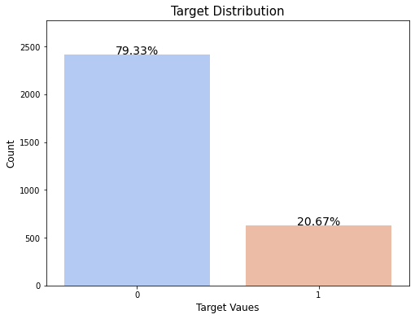

```python
# Code from
# https://www.kaggle.com/vikassingh1996/don-t-underestimate-the-power-of-a-logistic-reg

total = len(df)
plt.figure(figsize=(8,6))
g = sns.countplot(x='target', data=df, palette='coolwarm')
g.set_title("Target Distribution", fontsize = 15)
g.set_xlabel("Target Vaues", fontsize = 12)
g.set_ylabel("Count", fontsize = 12)
sizes=[] # Get highest values in y
for p in g.patches:
    height = p.get_height()
    sizes.append(height)
    g.text(p.get_x()+p.get_width()/2.,
            height + 3,
            '{:1.2f}%'.format(height/total*100),
            ha="center", fontsize=14)
g.set_ylim(0, max(sizes) * 1.15) # set y limit based on highest heights
```

## Drop columns with >40% missing

```python
def get_high_missing_cols(df, thresh=40):
    count = 0
    missing_cols = []
    num_records = len(df)
    for c in df.columns:
        perc_missing = (df[c].isna().sum() / num_records)*100
        if perc_missing > thresh:
            print(f"{c} has {perc_missing:.3f}% missing")
            count += 1
            missing_cols.append(c)
    print(f"Num cols with more than {thresh}% missing: {count}")
    return missing_cols
```

```python
missing_cols = get_high_missing_cols(df, thresh=40)
valid_cols = [c for c in df.columns if c not in missing_cols]
# df = df.loc[:,valid_cols]
```

```
member_id has 100.000% missing
desc has 90.437% missing
mths_since_last_delinq has 50.016% missing
mths_since_last_record has 82.649% missing
next_pymnt_d has 100.000% missing
mths_since_last_major_derog has 73.316% missing
annual_inc_joint has 97.601% missing
dti_joint has 97.601% missing
verification_status_joint has 97.634% missing
open_acc_6m has 60.532% missing
open_act_il has 60.532% missing
open_il_12m has 60.532% missing
open_il_24m has 60.532% missing
mths_since_rcnt_il has 61.551% missing
total_bal_il has 60.532% missing
il_util has 65.955% missing
open_rv_12m has 60.532% missing
open_rv_24m has 60.532% missing
max_bal_bc has 60.532% missing
all_util has 60.532% missing
inq_fi has 60.532% missing
total_cu_tl has 60.532% missing
inq_last_12m has 60.532% missing
mths_since_recent_bc_dlq has 76.109% missing
mths_since_recent_revol_delinq has 66.480% missing
revol_bal_joint has 98.193% missing
sec_app_fico_range_low has 98.193% missing
sec_app_fico_range_high has 98.193% missing
sec_app_earliest_cr_line has 98.193% missing
sec_app_inq_last_6mths has 98.193% missing
sec_app_mort_acc has 98.193% missing
sec_app_open_acc has 98.193% missing
sec_app_revol_util has 98.225% missing
sec_app_open_act_il has 98.193% missing
sec_app_num_rev_accts has 98.193% missing
sec_app_chargeoff_within_12_mths has 98.193% missing
sec_app_collections_12_mths_ex_med has 98.193% missing
sec_app_mths_since_last_major_derog has 99.211% missing
hardship_type has 99.573% missing
hardship_reason has 99.573% missing
hardship_status has 99.573% missing
deferral_term has 99.573% missing
hardship_amount has 99.573% missing
hardship_start_date has 99.573% missing
hardship_end_date has 99.573% missing
payment_plan_start_date has 99.573% missing
hardship_length has 99.573% missing
hardship_dpd has 99.573% missing
hardship_loan_status has 99.573% missing
orig_projected_additional_accrued_interest has 99.770% missing
hardship_payoff_balance_amount has 99.573% missing
hardship_last_payment_amount has 99.573% missing
debt_settlement_flag_date has 97.601% missing
settlement_status has 97.601% missing
settlement_date has 97.601% missing
settlement_amount has 97.601% missing
settlement_percentage has 97.601% missing
settlement_term has 97.601% missing
Num cols with more than 40% missing: 58
```

## Variables at loan application time

Because the dataset is a historical snapshot, not all variables in the data are available to LC at the time a loan application is being evaluated. For example, the variable `total_pymnt` measures the payments received to date for the total amount funded for a given loan. The value for this comes long after the lifecycle of a loan is completed (where it ends at either being 'Fully Paid' or 'Charged Off'). As such, at the time a loan application is being evaluated, information from this feature is unavailable.

To get the list of variables available at loan application time, I borrow the list of variables to keep from work undertaken in this Kaggle notebook

https://www.kaggle.com/pileatedperch/predicting-charge-off-from-initial-listing-data

```python
keep_list = ['addr_state', 'annual_inc', 'application_type',
             'dti', 'earliest_cr_line', 'emp_length',
             'emp_title', 'fico_range_high', 'fico_range_low',
             'grade', 'home_ownership', 'id', 'initial_list_status',
             'installment', 'int_rate', 'issue_d', 'loan_amnt',
             'mort_acc', 'open_acc', 'pub_rec', 'pub_rec_bankruptcies',
             'purpose', 'revol_bal', 'revol_util', 'sub_grade', 'term',
             'title', 'total_acc', 'verification_status', 'zip_code',
             'target']
keep_list.sort()
df = df[keep_list]
```

## Convert dates to datetime object

```python
dates_cols = ['earliest_cr_line', 'issue_d']
for c in dates_cols:
    df[c] = pd.to_datetime(df[c], format='%b-%Y')
    display(df[c].dt.year.value_counts())
```

```
2003    230
2002    220
2001    205
1999    183
2000    183
2004    180
2005    169
2006    149
1998    145
1997    141
1996    117
1994    110
1995    109
2007    106
1993     76
```

[output cut: 39 more lines]

```
2015    821
2016    665
2014    504
2017    388
2013    358
2018    119
2012    105
2011     41
2010     24
2009     12
2008      6
Name: issue_d, dtype: int64
```

## Diff between issue_d and earliest_cr_line

Number of days between the issue date of a loan and the earliest reported credit line opened by the applicant

```python
df['days_from_issue_to_earliest_cr'] = (df['issue_d'] - df['earliest_cr_line']).apply(lambda x: x.days)
```

## Convert object dtypes to categorical type

```python
cats_cols = df.select_dtypes('object').columns
df[cats_cols] = df[cats_cols].astype('category')
print(cats_cols)
```

```
Index(['addr_state', 'application_type', 'emp_length', 'emp_title', 'grade',
       'home_ownership', 'initial_list_status', 'purpose', 'sub_grade', 'term',
       'title', 'verification_status', 'zip_code'],
      dtype='object')
```

## Date restriction: splits train and OOS set

- Split training set from out-of-sample set based on year

```python
loan_years_training = [2013, 2014, 2015]
df_train = df[df['issue_d'].dt.year.isin(loan_years_training)]
df_train.shape

loan_years_oos = [2016]
df_oos = df[df['issue_d'].dt.year.isin(loan_years_oos)]
```

```python
df_train.shape, df_oos.shape
```

```
((1683, 32), (665, 32))
```

# Features

## Categorical variables

```python
utils.summarize_cats(df_train, cat_cols=cats_cols)
```

```
Dataset Shape: (1683, 13)
```

|  | Column Name | dtypes | Missing | Uniques | Values | Entropy |
| --- | --- | --- | --- | --- | --- | --- |
| 0 | addr_state | category | 0 | 47 | TX \| FL \| WV \| NY \| WA \| CO \| VA \| CT \| NM \| M... | 4.83 |
| 1 | application_type | category | 0 | 2 | Individual \| Joint App | 0.01 |
| 2 | emp_length | category | 76 | 11 | 2 years \| 4 years \| 10+ years \| 9 years \| 6 ye... | 3.04 |
| 3 | emp_title | category | 87 | 1273 | Chiropractor \| Accounts payable \| General Mana... | 10.01 |
| 4 | grade | category | 0 | 7 | D \| C \| A \| B \| F \| E \| G | 2.31 |
| 5 | home_ownership | category | 0 | 3 | MORTGAGE \| OWN \| RENT | 1.33 |
| 6 | initial_list_status | category | 0 | 2 | f \| w | 1.00 |
| 7 | purpose | category | 0 | 13 | debt_consolidation \| credit_card \| home_improv... | 1.79 |
| 8 | sub_grade | category | 0 | 34 | D3 \| D4 \| C2 \| A2 \| B4 \| C3 \| A1 \| B3 \| B5 \| A... | 4.59 |
| 9 | term | category | 0 | 2 | 36 months \| 60 months | 0.81 |
| 10 | title | category | 0 | 221 | Memorial \| Debt consolidation \| helpmehelpmyse... | 3.38 |
| 11 | verification_status | category | 0 | 3 | Not Verified \| Source Verified \| Verified | 1.57 |
| 12 | zip_code | category | 0 | 531 | 770xx \| 335xx \| 774xx \| 268xx \| 322xx \| 121xx ... | 8.54 |

We exclude emp_title because of the inconsistent classification used across loan applications. For example, nurses could be classified as a 'Nurse', 'Registered Nurse', 'RN', etc. This is an important category, but I suspect that it will likely be highly correlated with income.

The variables 'title' and 'purpose' captures similar information. 'purpose' however has lower cardinality and the classes appears to be standardized. As such, we exclude 'title' from our list of categorical variables.

From the summary above, we classify each categorical as follows.

```python
# Nominal
nom_cats_cols = ['addr_state', 'application_type',
                 'home_ownership', 'initial_list_status', 'purpose',
                 'term', 'verification_status', 'zip_code']
# Ordinal
ord_cats_cols = ['emp_length', 'grade', 'sub_grade']
```

```python
df['emp_length'].unique().tolist()
df['grade'].unique().tolist()
df['sub_grade'].unique().tolist()
```

```
['A1',
 'D3',
 'D4',
 'C2',
 'D5',
 'D2',
 'B2',
 'B3',
 'A3',
 'E4',
 'E5',
 'A2',
 'C5',
 'B4',
 'C3',
 'D1',
 'B5',
 'A4',
 'A5',
 'C1',
 'F1',
 'E2',
 'C4',
 'B1',
 'F2',
 'F5',
 'E3',
 'E1',
 'G4',
 'F3',
 'F4',
 'G1',
 'G2',
 'G3',
 'G5']
```

## Numerical variables

```python
num_cols = df_train.select_dtypes(np.number).columns.tolist()
num_cols.remove('id')
num_cols.remove('target')
utils.summarize_num(df_train, num_cols=num_cols)
```

|  | Column Name | dtypes | Count | Missing | Mean | Std. Dev | Min | 25% | 50% | 75% | Max |
| --- | --- | --- | --- | --- | --- | --- | --- | --- | --- | --- | --- |
| 0 | annual_inc | float64 | 1683 | 0 | 71,245.73 | 44,174.29 | 9,000.00 | 44,400.00 | 61,000.00 | 87,024.00 | 749,810.00 |
| 1 | dti | float64 | 1683 | 0 | 18.12 | 8.33 | 0.00 | 11.76 | 17.72 | 24.12 | 43.98 |
| 2 | fico_range_high | float64 | 1683 | 0 | 697.29 | 30.55 | 664.00 | 674.00 | 689.00 | 709.00 | 850.00 |
| 3 | fico_range_low | float64 | 1683 | 0 | 693.29 | 30.54 | 660.00 | 670.00 | 685.00 | 705.00 | 845.00 |
| 4 | installment | float64 | 1683 | 0 | 430.48 | 242.30 | 32.27 | 258.75 | 373.47 | 570.37 | 1,291.30 |
| 5 | int_rate | float64 | 1683 | 0 | 13.25 | 4.32 | 5.32 | 9.99 | 12.99 | 15.88 | 27.31 |
| 6 | loan_amnt | float64 | 1683 | 0 | 14,241.25 | 8,239.99 | 1,000.00 | 8,000.00 | 12,000.00 | 20,000.00 | 35,000.00 |
| 7 | mort_acc | float64 | 1683 | 0 | 1.76 | 2.13 | 0.00 | 0.00 | 1.00 | 3.00 | 16.00 |
| 8 | open_acc | float64 | 1683 | 0 | 11.11 | 5.04 | 2.00 | 8.00 | 10.00 | 14.00 | 45.00 |
| 9 | pub_rec | float64 | 1683 | 0 | 0.21 | 0.59 | 0.00 | 0.00 | 0.00 | 0.00 | 12.00 |
| 10 | pub_rec_bankruptcies | float64 | 1683 | 0 | 0.14 | 0.38 | 0.00 | 0.00 | 0.00 | 0.00 | 3.00 |
| 11 | revol_bal | float64 | 1683 | 0 | 15,877.32 | 20,925.93 | 0.00 | 5,747.50 | 10,998.00 | 18,529.00 | 345,501.00 |
| 12 | revol_util | float64 | 1683 | 0 | 54.21 | 23.79 | 0.00 | 36.65 | 54.60 | 73.30 | 105.80 |
| 13 | total_acc | float64 | 1683 | 0 | 24.87 | 12.05 | 3.00 | 16.00 | 23.00 | 31.00 | 87.00 |
| 14 | days_from_issue_to_earliest_cr | int64 | 1683 | 0 | 5,963.88 | 2,729.01 | 1,156.00 | 4,093.00 | 5,418.00 | 7,366.00 | 19,570.00 |

```python
# Compare distribution of features between each class in target
utils.print_full(df_train[num_cols+['target']].groupby('target').describe().T, num_rows=1000)
```

|  | target | 0 | 1 |
| --- | --- | --- | --- |
| annual_inc | count | 1,352.00 | 331.00 |
|  | mean | 72,126.70 | 67,647.32 |
|  | std | 42,431.46 | 50,587.07 |
|  | min | 9,000.00 | 14,028.00 |
|  | 25% | 45,000.00 | 41,061.56 |
|  | 50% | 62,000.00 | 59,000.00 |
|  | 75% | 89,000.00 | 80,000.00 |
|  | max | 444,000.00 | 749,810.00 |
| dti | count | 1,352.00 | 331.00 |
|  | mean | 17.75 | 19.64 |
|  | std | 8.30 | 8.33 |
|  | min | 0.00 | 0.67 |
|  | 25% | 11.40 | 13.85 |
|  | 50% | 17.59 | 18.88 |
|  | 75% | 23.67 | 25.84 |
|  | max | 43.98 | 39.52 |
| fico_range_high | count | 1,352.00 | 331.00 |
|  | mean | 698.51 | 692.29 |
|  | std | 31.19 | 27.24 |
|  | min | 664.00 | 664.00 |
|  | 25% | 674.00 | 674.00 |
|  | 50% | 689.00 | 684.00 |
|  | 75% | 714.00 | 704.00 |
|  | max | 850.00 | 809.00 |
| fico_range_low | count | 1,352.00 | 331.00 |
|  | mean | 694.51 | 688.29 |
|  | std | 31.19 | 27.24 |
|  | min | 660.00 | 660.00 |
|  | 25% | 670.00 | 670.00 |
|  | 50% | 685.00 | 680.00 |

[output cut: 90 more lines]

# Modelling

I use LightGBM for the baseline model. The model is widely used in Kaggle competitions and is suitable for this problem given the amount of data available. I train and validate in 2013-2015 (inclusive) and evaluate the model in 2016. I do very little feature engineering besides identifying categorical features and passing in the variable names of these features into LightGBM (an approach that is know to improve model performance). I also allow LightGBM to make the decision on [how to treat null values](https://github.com/Microsoft/LightGBM/blob/master/docs/Advanced-Topics.rst#missing-value-handle).

My modelling approach follows the [technique on this page](https://www.kaggle.com/sishihara/simple-lightgbm-kfold). I fit K models across the K folds using cross validation. For each fold, I set LightGBM to stop training if the validation error fails to improve within 200 iterations. I use the average prediction made by each K models as the final prediction for the evaluation set (2016 loan application data). Because the classes are imbalanced, I use the [average precision score](https://scikit-learn.org/stable/modules/generated/sklearn.metrics.average_precision_score.html) as the objective function to maximize.

Other approaches I could have taken to preprocess the categorical features include

- Encoding ordinal categorical features by assigning them a numeric ranking
- Applying either one-hot or target encoding (for high cardinality categorical features) on the nominal categorical features

```python
from functools import partial

import eli5
import lightgbm as lgb
from sklearn.model_selection import KFold
from lightgbm import LGBMClassifier
from sklearn.metrics import roc_auc_score
from sklearn import metrics
from eli5.sklearn import PermutationImportance
```

```python
# Cols to use for training
print(num_cols,
      nom_cats_cols,
      ord_cats_cols, sep='\n')
print("id col: id")
print("target col: target")
df_train[num_cols+nom_cats_cols+ord_cats_cols].info(verbose=2)
```

```
['annual_inc', 'dti', 'fico_range_high', 'fico_range_low', 'installment', 'int_rate', 'loan_amnt', 'mort_acc', 'open_acc', 'pub_rec', 'pub_rec_bankruptcies', 'revol_bal', 'revol_util', 'total_acc', 'days_from_issue_to_earliest_cr']
['addr_state', 'application_type', 'home_ownership', 'initial_list_status', 'purpose', 'term', 'verification_status', 'zip_code']
['emp_length', 'grade', 'sub_grade']
id col: id
target col: target
<class 'pandas.core.frame.DataFrame'>
Int64Index: 1683 entries, 1 to 4994
Data columns (total 26 columns):
annual_inc                        1683 non-null float64
dti                               1683 non-null float64
fico_range_high                   1683 non-null float64
fico_range_low                    1683 non-null float64
installment                       1683 non-null float64
int_rate                          1683 non-null float64
loan_amnt                         1683 non-null float64
mort_acc                          1683 non-null float64
open_acc                          1683 non-null float64
pub_rec                           1683 non-null float64
pub_rec_bankruptcies              1683 non-null float64
revol_bal                         1683 non-null float64
revol_util                        1683 non-null float64
total_acc                         1683 non-null float64
days_from_issue_to_earliest_cr    1683 non-null int64
addr_state                        1683 non-null category
application_type                  1683 non-null category
home_ownership                    1683 non-null category
initial_list_status               1683 non-null category
purpose                           1683 non-null category
term                              1683 non-null category
verification_status               1683 non-null category
zip_code                          1683 non-null category
emp_length                        1607 non-null category
grade                             1683 non-null category
sub_grade                         1683 non-null category
dtypes: category(11), float64(14), int64(1)
memory usage: 261.7 KB
```

## Model Training

```python
all_cols = num_cols + nom_cats_cols + ord_cats_cols
all_cats_cols = nom_cats_cols + ord_cats_cols
```

```python
# Prepare training data for modelling
X_train = df_train.drop('target', axis=1)
y_train = df_train['target']
X_train.shape, y_train.shape
```

```
((1683, 31), (1683,))
```

```python
def avg_precision_score(y_true, y_pred):
    '''average precision score for the LightGBM Sklearn API
    Source: https://github.com/microsoft/LightGBM/issues/2182
    '''
    is_higher_better = True
    return 'avg_precision_score', metrics.average_precision_score(y_true, y_pred), is_higher_better
```

```python
def train_lgbm(df_train, n_splits):
    lgb_params = {
        'objective': "binary",
        'boosting': "gbdt",
        'n_estimators': 2000,
        'learning_rate': 0.01,
        'num_leaves': 50,
        'min_data_in_leaf': 50,
        'colsample_bytree': .8,
        'subsample': .9,
        'max_depth': 8,
        'reg_alpha': .1,
        'reg_lambda': .1,
        'min_split_gain': .01,
        'min_child_weight': 2,
        'bagging_fraction': .5,
        'bagging_freq':100,
        'scale_pos_weight':2
    }

    eval_metric = avg_precision_score
#     eval_metric = 'auc'

    val_preds = np.zeros(X_train.shape[0])
    models = []

    folds = KFold(n_splits=n_splits, shuffle=True, random_state=42)
    for n_fold, (trn_idx, val_idx) in enumerate(folds.split(df_train)):

        trn_x, trn_y = X_train[all_cols].iloc[trn_idx], y_train.iloc[trn_idx]
        val_x, val_y = X_train[all_cols].iloc[val_idx], y_train.iloc[val_idx]

        lgb_model = LGBMClassifier(**lgb_params)
        lgb_model.fit(trn_x, trn_y,
                eval_set=[(trn_x, trn_y), (val_x, val_y)],
                eval_metric=eval_metric,
                verbose=200,
                early_stopping_rounds=200,
                categorical_feature=all_cats_cols)

        # Generate predictions based on best num. of iterations
        # and save to an array
        best_iter = lgb_model.best_iteration_
        val_preds[val_idx] = lgb_model.predict_proba(val_x,
                                               num_iteration=best_iter)[:, 1]

        print(f"Best number of iteration for fold {n_fold}: {best_iter} \n")

        # Save models for oos prediction
        models.append(lgb_model)

    print('ROC AUC: %.6f' % roc_auc_score(y_train, val_preds))
    print('PR AUC: %.6f' % metrics.average_precision_score(y_train, val_preds))
    return models, val_preds
```

```python
n_splits = 5
models, val_preds = train_lgbm(df_train, n_splits=n_splits)
```

```
Training until validation scores don't improve for 200 rounds
```

```
[200]	training's binary_logloss: 0.437369	training's avg_precision_score: 0.539994	valid_1's binary_logloss: 0.469492	valid_1's avg_precision_score: 0.266431
Early stopping, best iteration is:
[26]	training's binary_logloss: 0.485977	training's avg_precision_score: 0.421046	valid_1's binary_logloss: 0.447523	valid_1's avg_precision_score: 0.269878
Best number of iteration for fold 0: 26

Training until validation scores don't improve for 200 rounds
[200]	training's binary_logloss: 0.427676	training's avg_precision_score: 0.535065	valid_1's binary_logloss: 0.503844	valid_1's avg_precision_score: 0.30402
Early stopping, best iteration is:
[1]	training's binary_logloss: 0.491415	training's avg_precision_score: 0.319941	valid_1's binary_logloss: 0.505985	valid_1's avg_precision_score: 0.30919
Best number of iteration for fold 1: 1

Training until validation scores don't improve for 200 rounds
[200]	training's binary_logloss: 0.440406	training's avg_precision_score: 0.540754	valid_1's binary_logloss: 0.48329	valid_1's avg_precision_score: 0.251697
Early stopping, best iteration is:
[19]	training's binary_logloss: 0.48403	training's avg_precision_score: 0.377191	valid_1's binary_logloss: 0.471304	valid_1's avg_precision_score: 0.273675
Best number of iteration for fold 2: 19

Training until validation scores don't improve for 200 rounds
[200]	training's binary_logloss: 0.425171	training's avg_precision_score: 0.56252	valid_1's binary_logloss: 0.510946	valid_1's avg_precision_score: 0.266242
Early stopping, best iteration is:
[25]	training's binary_logloss: 0.476282	training's avg_precision_score: 0.395556	valid_1's binary_logloss: 0.479999	valid_1's avg_precision_score: 0.267799
Best number of iteration for fold 3: 25

Training until validation scores don't improve for 200 rounds
[200]	training's binary_logloss: 0.405044	training's avg_precision_score: 0.551967	valid_1's binary_logloss: 0.526272	valid_1's avg_precision_score: 0.371734
Early stopping, best iteration is:
[175]	training's binary_logloss: 0.410181	training's avg_precision_score: 0.53994	valid_1's binary_logloss: 0.525647	valid_1's avg_precision_score: 0.371732
Best number of iteration for fold 4: 175

ROC AUC: 0.616385
PR AUC: 0.284764
```

```python
preds, preds_2d, preds_class = utils.create_prediction_class(val_preds)
```

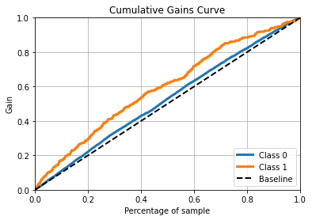

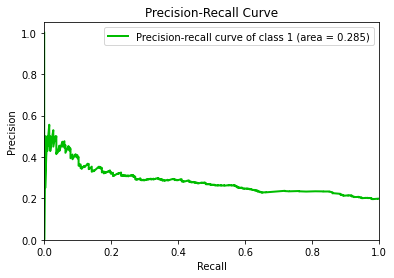

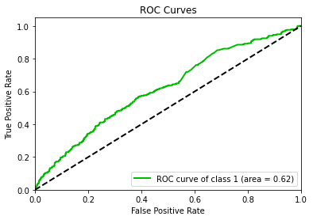

```python
utils.gen_gains_pr_roc_plots(y_train, preds_2d, RESULTS_PATH)
```

```python
preds, preds_2d, preds_class = \
    utils.create_prediction_class(val_preds, threshold=.2)
utils.scores(y_train, preds_class, preds);
```

```
>>> Scores <<<
Accuracy: 0.4973
ROC AUC: 0.6164
F1 Score: 0.3380
Avg. Precision: 0.2848
```

```
Gain-based feature importance
Model: 0
```

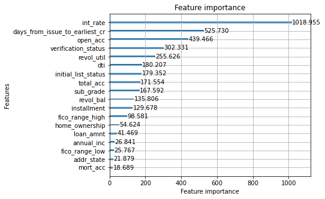

```
Model: 1
```

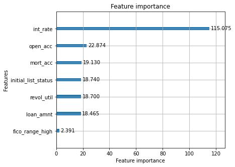

```
Model: 2
```

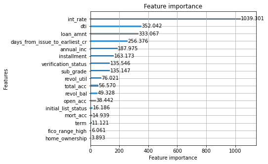

```
Model: 3
```

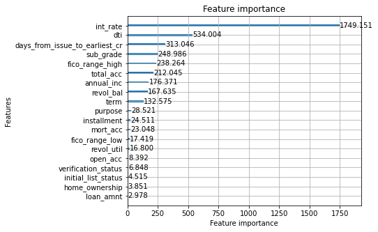

```
Model: 4
```

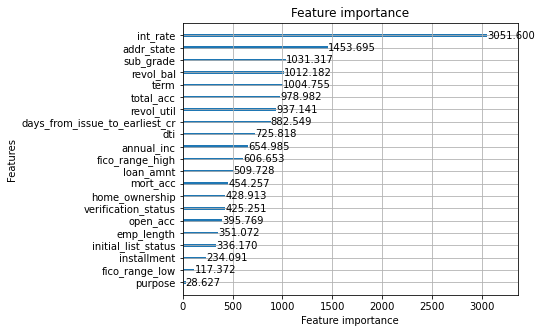

```python
print("Gain-based feature importance")
for i, m in enumerate(models):
    print(f"Model: {i}")
    lgb.plot_importance(m, figsize=(6,5), importance_type='gain')
    plt.show()
```

# Model Evaluation on 2016 OOS set

We evaluate the model on the 2016 loan applications.

```python
# OOS set
X_test = df_oos.drop('target', axis=1)
y_test = df_oos['target']
X_test.shape, y_test.shape
```

```
((665, 31), (665,))
```

```python
# Generate average prediction across the k-folds for
# each record in the OOS set
sub_preds = np.zeros(X_test.shape[0])
for m in models:
    best_iter = m.best_iteration_
    print("Number of trees with early stopping (max == 2000):", best_iter)
    sub_preds += m.predict_proba(X_test[all_cols],
                                 num_iteration=best_iter)[:, 1] / n_splits
```

```
Number of trees with early stopping (max == 2000): 26
Number of trees with early stopping (max == 2000): 1
Number of trees with early stopping (max == 2000): 19
Number of trees with early stopping (max == 2000): 25
Number of trees with early stopping (max == 2000): 175
```

```python
# Create dataset containing ground truth, predictions and loan
# issue date for 2016
results_2016 = pd.DataFrame({
    'id': X_test['id'],
    'y_test': y_test,
    'y_preds': sub_preds,
    'issue_d': X_test['issue_d'],
})
```

```python
# Create various arrays related to predictions, predicted class, etc.
# for visualization purposes
preds, preds_2d, preds_class = \
utils.create_prediction_class(sub_preds, threshold=.3)
```

```python
pd.DataFrame(preds).describe()
```

|  | 0 |
| --- | --- |
| count | 665.000000 |
| mean | 0.224098 |
| std | 0.040832 |
| min | 0.153419 |
| 25% | 0.189570 |
| 50% | 0.217356 |
| 75% | 0.254642 |
| max | 0.338603 |

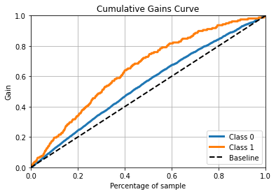

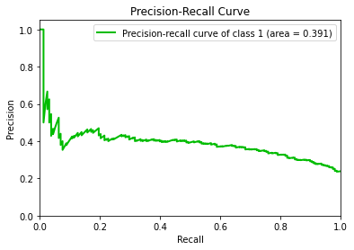

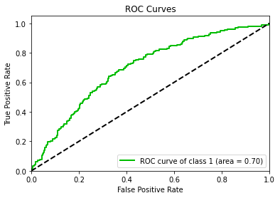

```python
utils.gen_gains_pr_roc_plots(y_test, preds_2d, RESULTS_PATH)
```

```python
threshold = 0.2
preds, preds_2d, preds_class = \
utils.create_prediction_class(sub_preds, threshold=threshold)
cm = utils.gen_confusion_matrix(y_test.values, preds_class.reshape((-1,)))
cm
```

|  | pred=0 | pred=1 | All |
| --- | --- | --- | --- |
| true=0 | 212 | 295 | 507 |
| true=1 | 25 | 133 | 158 |
| All | 237 | 428 | 665 |

# Q1: Visualizing predictions for each month of 2016

The second plot shows the deciles of the predictions (x-axis), plotted againts the number of charge offs in the decile (y-axis). More concretely, the height of the bar graph in each decile represents the number of charge offs in that decile. The 9th decile are the loan applications that are in the top 10 percent in probability of being a charge off. A deterioration occurs when the count of charge offs in the lower deciles increases relative to the count of charge offs in the top deciles. Looking at the counts of charge offs across the deciles over the year, this appears to be the case.

```python
preds_class.sum(), y_test.sum()
```

```
(428, 158)
```

```python
results_2016['month'] = results_2016['issue_d'].dt.month
results_2016['month'].value_counts()
```

```
3     115
2      78
1      64
4      55
7      53
6      51
11     47
9      46
5      42
10     41
8      41
12     32
Name: month, dtype: int64
```

```python
sub_preds.min()
```

```
0.15341932226017724
```

```python
from math import log
def logloss1(y, p):
    return -(y*log(p) + (1 - y)*log(1 - p))
```

```python
# Create column with logloss values
results_2016['logloss1'] = (
    results_2016.
    apply(lambda row: logloss1(row['y_test'], row['y_preds']), axis=1)
)
```

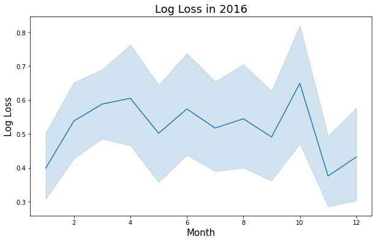

```python
fig, ax = plt.subplots(figsize=(10,6))
sns.lineplot(x='month', y='logloss1', data=results_2016);
ax.set_title('Log Loss in 2016', fontsize=18)
ax.set_xlabel('Month', fontsize=15)
ax.set_ylabel('Log Loss', fontsize=15)
```

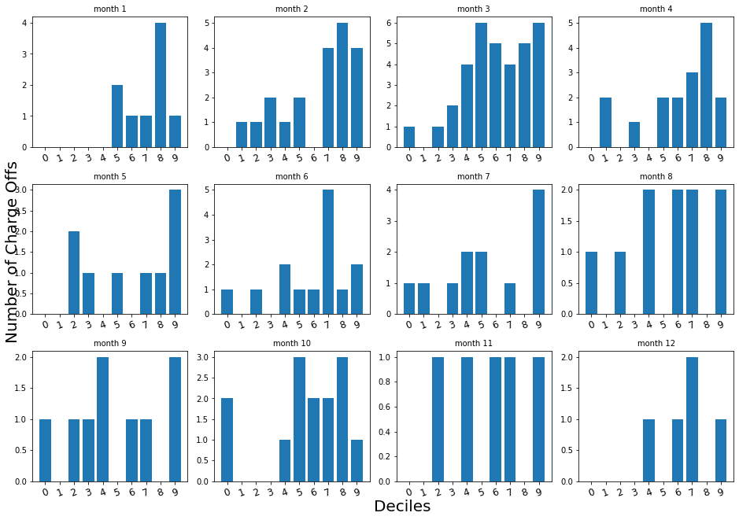

```python
months = results_2016.month.unique()
months.sort()

fig, ax = plt.subplots(figsize=(13,9))
for m in months:
    dff = results_2016[results_2016.month == m]

    plt.subplot(3, 4, m)

    # Build dataset
    result_df = pd.DataFrame()
    result_df['target'] = dff['y_test']
    result_df['predicted'] = dff['y_preds']
    result_df['decile'] = pd.qcut(result_df['predicted'], 10, labels=False)
    decile_df = (result_df.
                 groupby('decile').
                 agg({'target': ['sum'], 'predicted': ['mean']}))
    decile_df.columns = ['_'.join(c).strip() for c in decile_df.columns.values]
    index = np.arange(0, len(decile_df))

    plt.bar(index, decile_df['target_sum'])
    plt.xticks(index, fontsize=12, rotation=20)

    plt.title(f'month {m}', fontsize=10)

fig.text(0.00001, 0.5, 'Number of Charge Offs', va='center', rotation='vertical', fontsize=20)
fig.text(0.5, 0.00001, 'Deciles', va='center', rotation='horizontal', fontsize=20)
plt.tight_layout()
plt.show()
```

# Q2: Revenue analysis

To explore why revenues might have increased from using the model, we can look at a summary of the features between loans that are most likely to be a charge off and loans that are more likely to be paid off based on the predictions of the model. Below is the decile plot for all loan applications in 2016.

I split the 2016 dataset between those in the top deciles (deciles 7, 8 and 9) and compare their features with those in the bottom deciles (deciles 0, 1, and 2). Deciles are based on the predicted probabilities (the 9th decile represent the top 10 percent in predicted probabilities---those most likely to be charge offs).

Comparing the distribution of the features, the FICO scores (both low and high) are higher for those in the lower deciles (good borrowers). Similarly, interest rates are lower for this group. For the group in the upper deciles (bad borrowers), their FICO scores are lower and they also have a higher average interest rate.

High interest rates may result in higher expected revenue, but only if loans are paid at the end of their term. If the borrower's loan results in a charge off, we not only lose interest revenue, but the loan principal itself. The revenue may have increased because the model helped guide us to select only "good" borrowers.

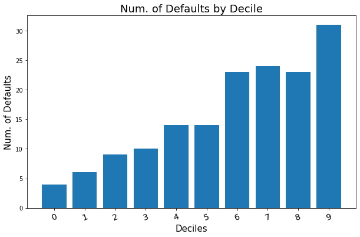

```python
deciles = utils.gen_deciles_plot(results_2016['y_test'],
                                 results_2016['y_preds'],
                                 title='Num. of Defaults by Decile',
                                 ylabel='Num. of Defaults'
                                )
```

```python
# Create a deciles column
results_2016['y_preds_deciles'] = pd.qcut(results_2016['y_preds'], 10, labels=False)

# Merge back features
d = pd.merge(results_2016, X_test, how='left', on='id', indicator=True)
d._merge.value_counts()
```

```
both          665
right_only      0
left_only       0
Name: _merge, dtype: int64
```

```python
# High probability of charge off groups
d.loc[d.y_preds_deciles.isin([7,8,9]), all_cols].describe().T
```

|  | count | mean | std | min | 25% | 50% | 75% | max |
| --- | --- | --- | --- | --- | --- | --- | --- | --- |
| annual_inc | 200.0 | 75029.46500 | 45059.239306 | 18240.00 | 45000.0000 | 62500.000 | 90000.0000 | 350000.00 |
| dti | 200.0 | 22.23665 | 9.171407 | 0.53 | 16.3450 | 21.785 | 28.7275 | 47.91 |
| fico_range_high | 200.0 | 687.55000 | 23.283214 | 664.00 | 669.0000 | 681.500 | 699.0000 | 809.00 |
| fico_range_low | 200.0 | 683.55000 | 23.283214 | 660.00 | 665.0000 | 677.500 | 695.0000 | 805.00 |
| installment | 200.0 | 547.17000 | 286.715618 | 39.76 | 346.2275 | 481.675 | 689.0075 | 1569.11 |
| int_rate | 200.0 | 18.22170 | 4.217215 | 9.75 | 15.3100 | 17.270 | 20.1800 | 30.94 |
| loan_amnt | 200.0 | 18105.87500 | 9164.710001 | 1000.00 | 10962.5000 | 16000.000 | 24737.5000 | 40000.00 |
| mort_acc | 200.0 | 1.51500 | 2.012467 | 0.00 | 0.0000 | 1.000 | 2.0000 | 12.00 |
| open_acc | 200.0 | 14.22000 | 6.653793 | 3.00 | 10.0000 | 13.000 | 17.0000 | 42.00 |
| pub_rec | 200.0 | 0.32000 | 0.741857 | 0.00 | 0.0000 | 0.000 | 0.0000 | 6.00 |
| pub_rec_bankruptcies | 200.0 | 0.20500 | 0.533289 | 0.00 | 0.0000 | 0.000 | 0.0000 | 5.00 |
| revol_bal | 200.0 | 16757.82000 | 12869.041324 | 3.00 | 7329.0000 | 13675.500 | 22633.2500 | 59980.00 |
| revol_util | 200.0 | 50.71850 | 22.094546 | 0.00 | 34.8500 | 50.100 | 65.3500 | 99.20 |
| total_acc | 200.0 | 29.00000 | 13.491483 | 4.00 | 19.7500 | 26.000 | 36.0000 | 86.00 |
| days_from_issue_to_earliest_cr | 200.0 | 5674.88000 | 2352.001020 | 1157.00 | 4201.5000 | 5114.000 | 6674.5000 | 17380.00 |

```python
# Low probability of charge off groups
d.loc[d.y_preds_deciles.isin([0,1,2]), all_cols].describe().T
```

|  | count | mean | std | min | 25% | 50% | 75% | max |
| --- | --- | --- | --- | --- | --- | --- | --- | --- |
| annual_inc | 200.0 | 86487.64140 | 52949.624389 | 21000.00 | 52000.0000 | 72500.000 | 108000.0000 | 375000.00 |
| dti | 200.0 | 15.37335 | 7.890968 | 0.78 | 9.1675 | 14.665 | 20.6725 | 41.43 |
| fico_range_high | 200.0 | 716.15000 | 33.541057 | 664.00 | 689.0000 | 714.000 | 735.2500 | 809.00 |
| fico_range_low | 200.0 | 712.15000 | 33.541057 | 660.00 | 685.0000 | 710.000 | 731.2500 | 805.00 |
| installment | 200.0 | 412.17865 | 255.461344 | 68.84 | 196.2400 | 332.765 | 602.3000 | 1309.36 |
| int_rate | 200.0 | 8.45785 | 2.164782 | 5.32 | 6.9700 | 8.240 | 9.9725 | 14.49 |
| loan_amnt | 200.0 | 13302.12500 | 8262.980415 | 2000.00 | 6000.0000 | 11000.000 | 20000.0000 | 40000.00 |
| mort_acc | 200.0 | 2.02000 | 2.014919 | 0.00 | 0.0000 | 2.000 | 3.0000 | 9.00 |
| open_acc | 200.0 | 10.99000 | 4.951006 | 3.00 | 7.7500 | 10.000 | 13.0000 | 26.00 |
| pub_rec | 200.0 | 0.24500 | 0.544479 | 0.00 | 0.0000 | 0.000 | 0.0000 | 3.00 |
| pub_rec_bankruptcies | 200.0 | 0.15000 | 0.397859 | 0.00 | 0.0000 | 0.000 | 0.0000 | 2.00 |
| revol_bal | 200.0 | 14679.58000 | 19314.798968 | 0.00 | 4820.7500 | 8638.500 | 17430.5000 | 147119.00 |
| revol_util | 200.0 | 40.24250 | 23.342067 | 0.00 | 20.6250 | 37.900 | 55.6500 | 99.20 |
| total_acc | 200.0 | 24.89500 | 11.188830 | 7.00 | 17.0000 | 23.000 | 30.2500 | 63.00 |
| days_from_issue_to_earliest_cr | 200.0 | 6888.94000 | 2844.235294 | 1430.00 | 4824.2500 | 6331.000 | 8575.7500 | 16983.00 |

```python
print("Finished!")
```

```
Finished!
```